# Binsmoothing and the Joys and Perils of CRAN

David J. Hunter, Westmont College

August 20, 2020

# Introduction

## These slides are available online

HTML Slides and related information can be found at: https://djhunter.github.io/binsmooth/

## Outline

- Smoothing binned data
  - The problem: measuring *income inequality* from census data.
  - Our idea: Smooth the bins to get a PDF.
- R lessons I learned
  - Using R with students
  - Submitting to CRAN
  - Using CRAN packages
- Discussion
  - Questions?
  - Share your CRAN stories.

# Smoothing binned data

## Measuring income inequality

The *Gini coefficient* $G$ is a measure of income inequality.

- $0 \leq G \leq 1$, where 0 is complete equality.
- On a set $\{x_1,x_2, \ldots, x_n\}$ of incomes, $G$ is an average of absolute differences:
  $$G = \frac{1}{2n^2\bar{x}} \sum_{j=1}^n \sum_{i=1}^n |x_i - x_j|$$
- **Problem:** Individual $x_i$’s are not publicly available.

| CA County | Gini |
| --- | --- |
| San Francisco | 0.507 |
| Santa Barbara | 0.475 |
| Napa | 0.399 |
| Sierra | 0.389 |

## Gini coefficient: continuous version

On a population with income density function $f(x)$,
$$G = \frac{1}{2\mu} \int_0^{\infty}\!\!\int_0^{\infty} f(x)f(y)|x-y| \, dx \, dy$$
(Assuming that our density functions have nonnegative support.)

- *Upshot:* We can estimate $G$ by estimating a PDF for an income distribution.
- `pracma::integral` is reasonably fast.

## Census data is binned

The `binsmooth` package includes some American Community Survey (ACS) data from 2006-2010.

```r
library(binsmooth)
library(tidyverse)
library(knitr)
data("county_bins")
county_bins %>%
  filter(county == "Santa Barbara County") %>%
  select(households, bin_min, bin_max) %>%
  kable()
```

| households | bin_min | bin_max |
| --- | --- | --- |
| 7181 | 0 | 9999 |
| 6690 | 10000 | 14999 |
| 6677 | 15000 | 19999 |
| 6598 | 20000 | 24999 |
| 6150 | 25000 | 29999 |
| 6759 | 30000 | 34999 |
| 6541 | 35000 | 39999 |
| 6293 | 40000 | 44999 |
| 6538 | 45000 | 49999 |
| 11384 | 50000 | 59999 |
| 15359 | 60000 | 74999 |
| 16912 | 75000 | 99999 |
| 12527 | 100000 | 124999 |
| 8774 | 125000 | 149999 |
| 8578 | 150000 | 199999 |
| 8832 | 200000 | NA |

## Smooth the bins to get a PDF

ACS binned data ➡ Approximated PDF ➡ Gini (from integral)

- Previous work tried to fit parametric distributions to the bins.
- Tested 3 *smoothing* methods: Step function, Recursive subdivision, Splines
- For the counties in `county_bins`, the Census Bureau computed the *actual Gini’s* from raw data!
  - Can compare our approximated Gini’s with the actual Gini’s to evaluate which method works best.
- *Every method works better if we also know the mean income.* These are in `county_true`. Since the top bin is unbounded, we adjust the tail of the PDF to fit the mean.

```r
data("county_true")
county_all <- left_join(county_bins, county_true, by="fips")
```

## Step function PDF

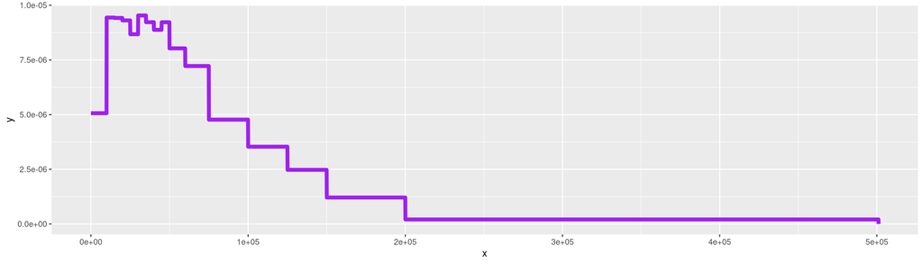

```r
library(magrittr)
county_all %>% filter(county == "Santa Barbara County") %$%
  stepbins(bin_max, households, mean_true[1]) -> sb
ggplot(data.frame(x=c(0,sb$E)), aes(x=x)) +  stat_function(fun = sb$stepPDF, n=5000, color="purple", size=2)
```

## Recursive subdivision

- Idea: Smooth the bins by subdividing and adjusting
- Maintain the total area of the original bins.

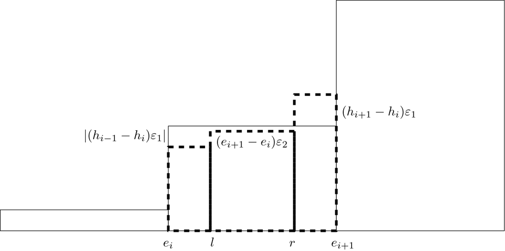

Default values: $\varepsilon_1 = 0.25$ and $\varepsilon_2 = 0.75$

## Recursive subdivision PDF

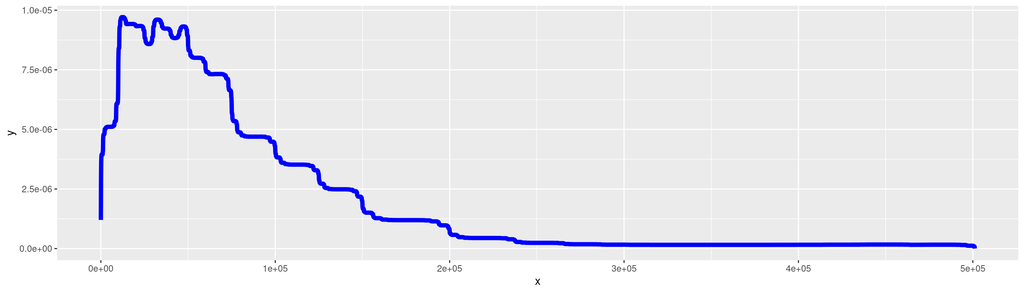

```r
county_all %>% filter(county == "Santa Barbara County") %$%
  rsubbins(bin_max, households, mean_true[1], depth=5) -> rs
ggplot(data.frame(x=c(0,rs$E)), aes(x=x)) +  stat_function(fun = rs$rsubPDF, n=5000, color="blue", size=2)
```

## How about splines?

- `stats::splinefun` will return a function that interpolates data points.
- Splining a PDF is tricky: tail goes haywire.
- Better: *Spline the CDF*, then differentiate!
  - Monotone functions spline better.
  - Also: preserves bin area, by construction.
  - Also: Gini (and mean) can be calculated from the CDF $F(x)$:

$$G = 1- \frac{1}{\mu} \int_0^{\infty} (1 - F(x))^2 \, dx \\
\mu = \int_0^\infty (1 - F(x)) \, dx$$
(because $f(x)$ has nonnegative support)

## PDF from splined CDF

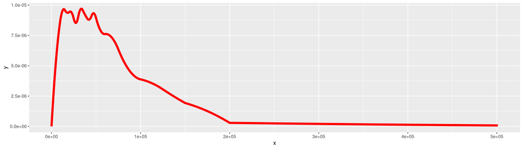

```r
county_all %>% filter(county == "Santa Barbara County") %$%
  splinebins(bin_max, households, mean_true[1]) -> sp
ggplot(data.frame(x=c(0,sb$E)), aes(x=x)) +  stat_function(fun = sp$splinePDF, n=5000, color="red", size=2)
```

## Step, Recsub, and Splined CDF

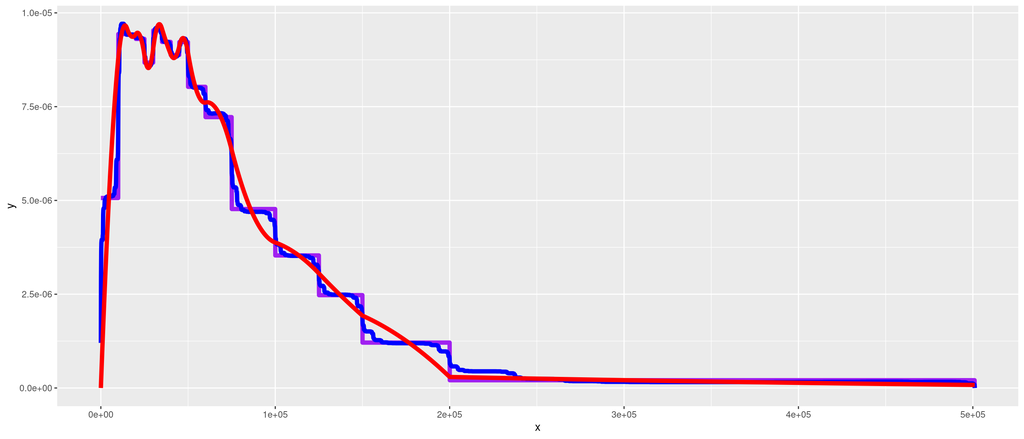

## Recovering the Gini

| Method | %RMSE | %Bias | %Reliable | Running time |
| --- | --- | --- | --- | --- |
| Step function | 1.1 | -0.3 | 98 | 46 sec |
| Recursive subdivision | 2.0 | -1.3 | 97 | 394 sec |
| Splined CDF | 1.1 | -0.6 | 99 | 223 sec |

*Fine Print:* For $1\leq j \leq 3221$, let $\{\theta_j\}$ be the set of published Gini’s, and let $\{\hat{\theta}_j\}$ be the corresponding estimates. If $e_j = 100(\hat{\theta}_j - \theta_j)/\theta_j$, then the *percent relative bias* (%Bias) is the mean of the set $\{e_j\}$, the *percent root mean squared error* (%RMSE) is the square root of the mean of $\{e_j^2\}$, and the *reliability* is the squared correlation between $\theta_j$ and $\hat{\theta}_j$.

# R lessons I learned

## Using R with students

[figure not shown]

## Using R with students

- Students can figure it out.
- Upper-division students: have them write packages.
  - Documentation tells them what is required.
  - Examples allow for testing.
- Lower-division students: assign RMarkdown “worksheets”.

## Example package assignment

```r
#' Discrete Logarithm (brute force)
#'
#' Computes a discrete logarithm by brute force.
#'
#' @param alpha The base, assumed to be a primitive root modulo p.
#' @param beta An element of Z_p
#' @param p A prime modulus.
#'
#' @return Computes L_alpha(beta), the smallest nonnegative integer x such that beta = alpha^x, modulo p.
#' @export
#' @import gmp
#'
#' @examples
#' discreteLogBrute(2,9,11) # should be 6
discreteLogBrute <- function(alpha, beta, p) {
  # TODO
}

#' Next Primitive Root
#'
#' Finds the next primitive root after \code{after} modulo \code{p}.
#'
#' @param p A prime number. Could be \code{bigz}.
#' @param after Number after which to start testing. Defaults to 1.
#'
#' @return The smallest primitive root modulo \code{p} greater than \code{after}. Applies
#' the procedure described in Exercise 21 on p. 107 of [Trappe].
#' @export
#' @import gmp
#'
#' @examples
#' nextPrimRoot(601) # See page 107, Problem 21
#' nextPrimRoot(nextprime(as.bigz("1203481092840918409408098")), 200) # should be 203
nextPrimRoot <- function(p, after = 1){
  # TODO
}

#' Solve a system using the Chinese Remainder Theorem
#'
#' Given a system of i congruences of the form x = a_i mod m_i, returns
#' the smallest positive x that satisifies all the congruences. Applies the
#' Chinese Remainder Theorem, following the procedure outlined
#' in [Trappe], p. 108, Problem 24. Works for bigz integers.
#'
#' @param a A vector of i integers (or bigz integers)
#' @param m A vector of i moduli (as integers or as bigz)
#'
#' @return A bigz integer solutions to the system.
#' @export
#' @import gmp
#'
#' @examples
#' crtSolve(c(2,1,3), c(5,6,7))
crtSolve <- function(a, m){
  # TODO
}
```

## Submitting to CRAN

> “CRAN hosts packages of publication quality and is not a development platform. A package’s contribution has to be non-trivial.”

My experience:

- Very reasonable process. Just be sure to follow all [the rules](https://cran.r-project.org/web/packages/policies.html).
- Publishing a CRAN package is a great way to get people to notice your work.
- However, people who use your package won’t necessarily [read your paper](https://sociologicalscience.com/articles-v4-26-641/).
  - Include **warnings** when users are doing it wrong.
- People will ask you to add functionality. You might break something.
- Corollary: Watch out when you use CRAN packages.

## Choosing an interface

- Probably you should think harder than I did about this.
- Arguments: right endpoints of each bin, counts, mean (optional)
- Returns: a list
- For example, see the [stepbins documentation](https://www.rdocumentation.org/packages/binsmooth/versions/0.2.2/topics/stepbins).

```r
stepbins <- function(bEdges, bCounts, m=NULL, tailShape = c("onebin", "pareto", "exponential"),
                     nTail=16, numIterations=20, pIndex=1.160964, tbRatio=0.8) {
  L <- length(bCounts)
  if(!(is.na(bEdges[L]) | is.infinite(bEdges[L])))
    warning("Top bin is bounded. Expect inaccurate results.\n")
  if(is.null(m)) { # no mean provided, so make one up
    warning("No mean provided: expect inaccurate results.\n")
    m <- sum(0.5*(c(bEdges[1:(L-1)],2.0*bEdges[L-1])+c(0, bEdges[1:(L-1)]))*bCounts/sum(bCounts))
  }
  tailShape <- match.arg(tailShape)
  if(tailShape == "onebin")
    stepbinsNotail(bEdges, bCounts, m)
  else
    stepbinsTail(bEdges, bCounts, m, tailShape, nTail, numIterations, pIndex, tbRatio)
}
```

## Discussion

- Questions?
- Any CRAN stories?
  - Ever submit a package? How was the review process for you?
  - Ever use a CRAN package that didn’t work?